# Titanic: l’inaffondabile gigante d’acciaio

2/9/2021

## L’ottava meraviglia del mondo moderno

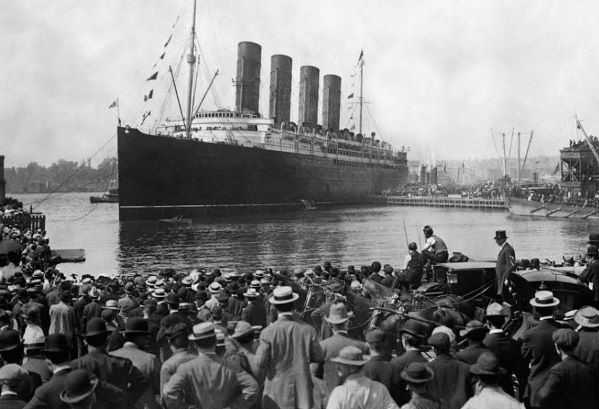

## Il dataset titanic

Il mio dataset si compone di 7 variabili:

1. **Survived**: sopravvissuto o deceduto
2. **Pclass**: classe passeggeri
3. **Age**: anni
4. **Sex**: sesso
5. **SibSp**: numero di fratelli/ sorelle/ coniugi
6. **Fare**: tariffa per passeggero
7. **Embarked**: porto di partenza

## Quante persone sono sopravvissute e quante sono decedute?

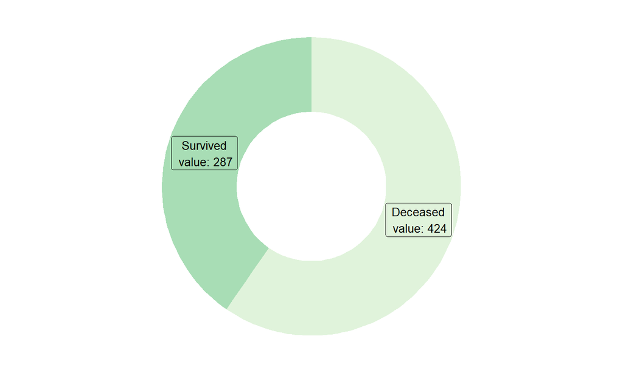

## C’erano più donne o più uomini a bordo?

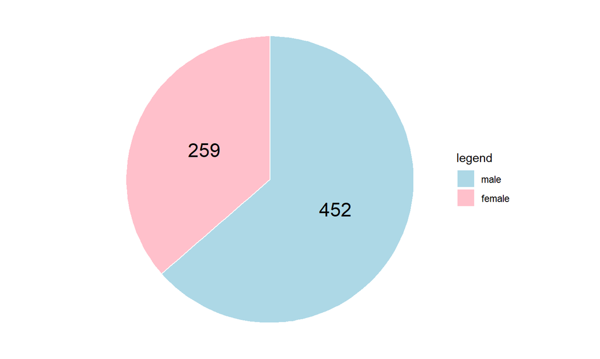

## Sono decedute o sopravvissute più donne o uomini?

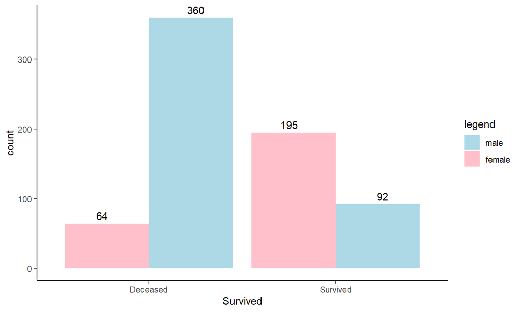

L’85% dei deceduti è di sesso maschile mentre il 68% dei sopravvissuti è di sesso femminile.

## Com’era distribuita l’età dei passeggeri?

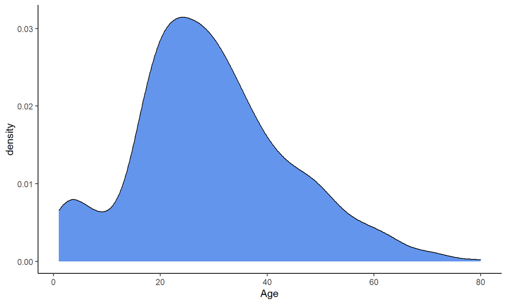

## Dividiamo per classi di età

Numerosità dei passeggeri per classi d’età e rispetto al sesso

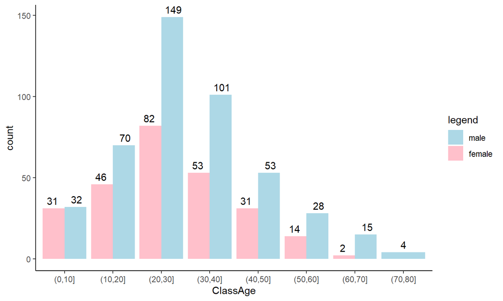

## Sono decedute più persone anziane o più giovani?

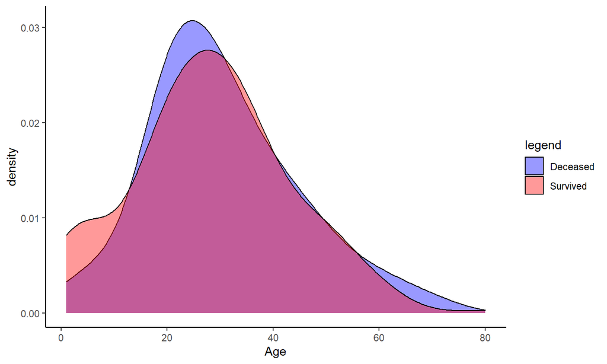

## A chi veniva data la precedenza per salvarsi? Agli uomini o alle donne?

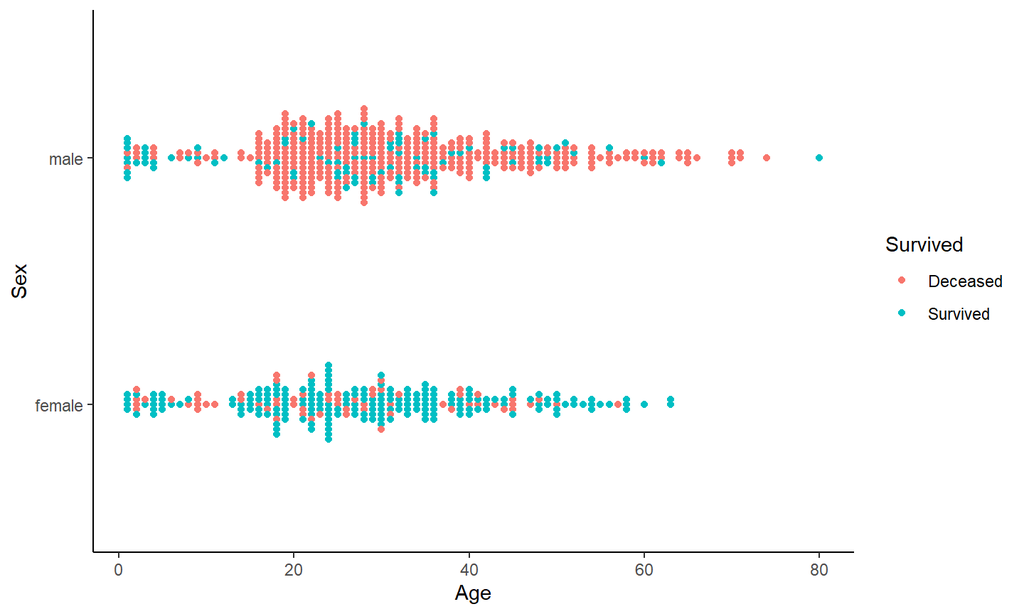

## C’erano più persone in prima, seconda o terza classe?

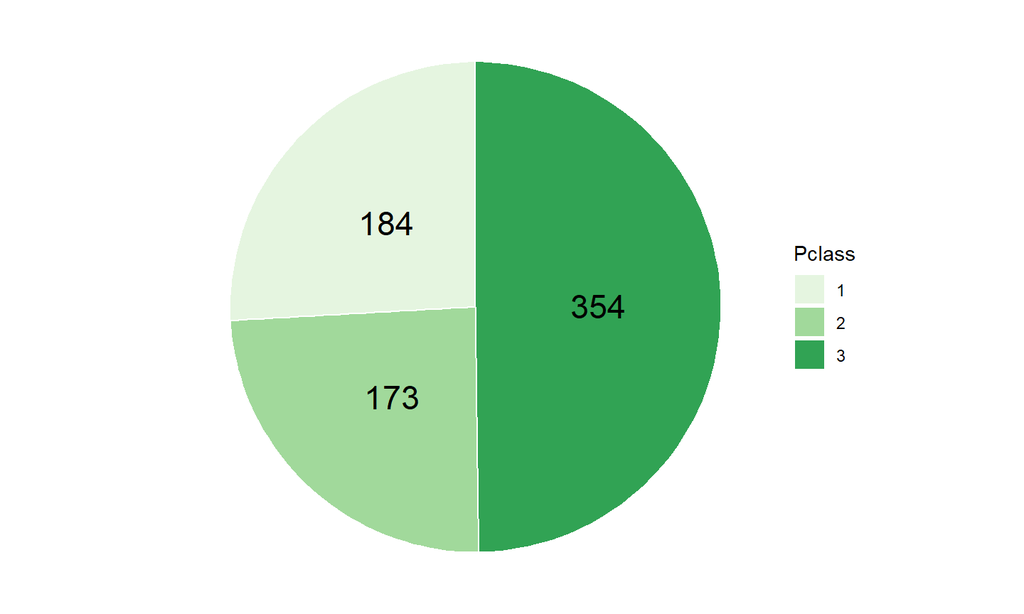

## Appartenere ad una classe piuttosto che ad un’altra ha influito sulla salvezza?

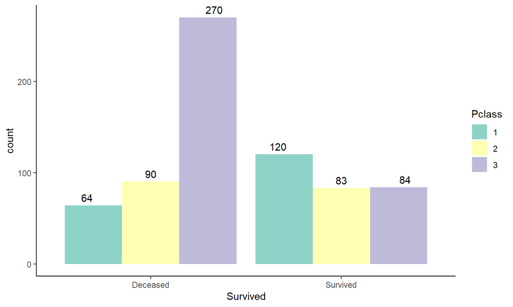

Più nello specifico:

Percentuale di passeggeri sopravvissuti di genere femminile divisi per classi di appartenenza

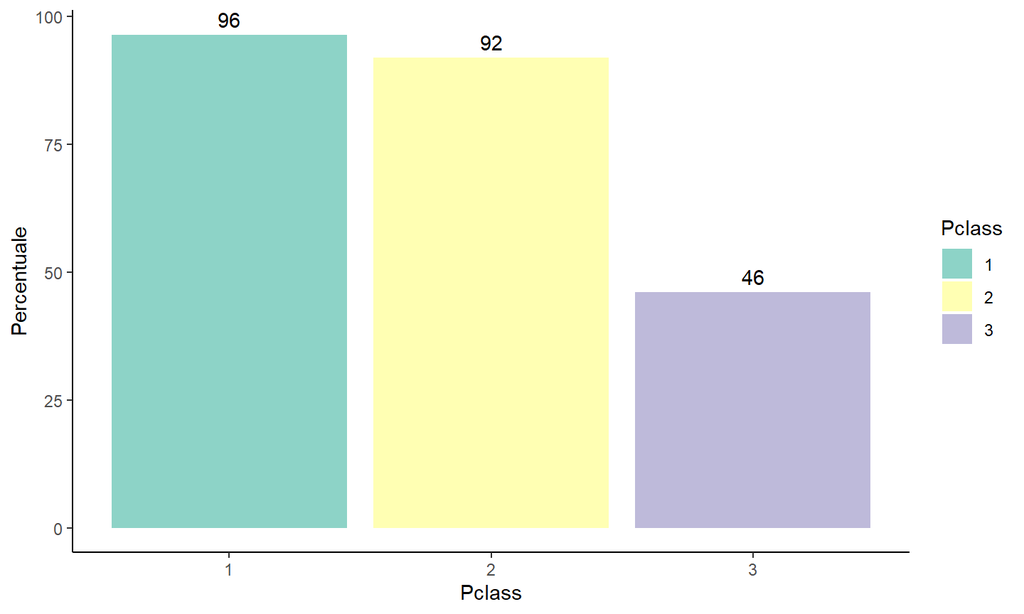

Percentuale di passeggeri sopravvissuti di genere maschile divisi per classi di appartenenza

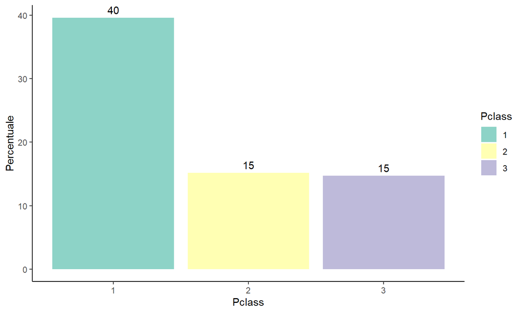

## Come varia l’età rispetto alla classe di appartenenza?

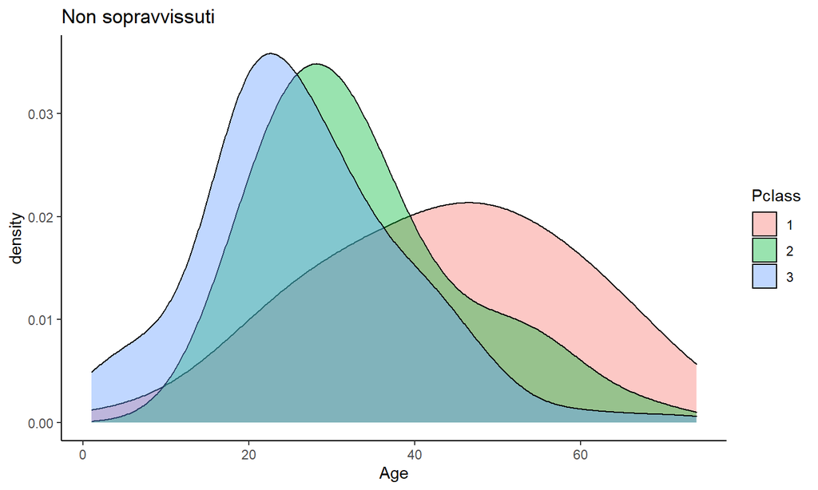

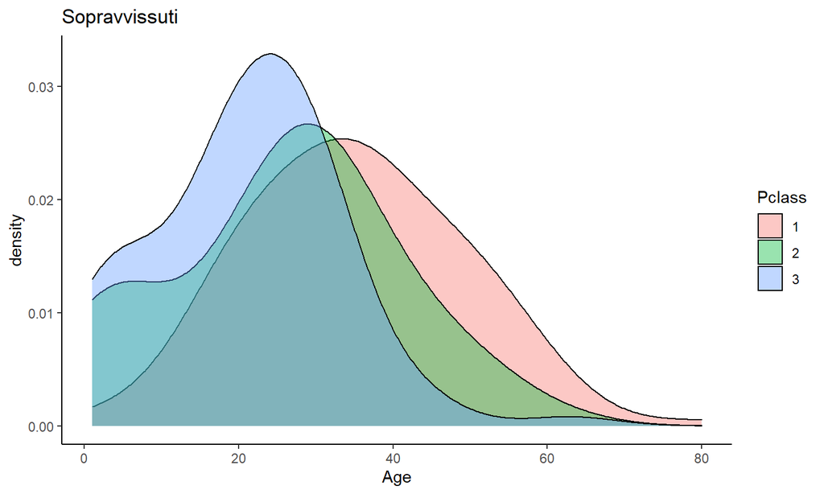

## Come cambia la sopravvivenza rispetto al porto d’imbarco?

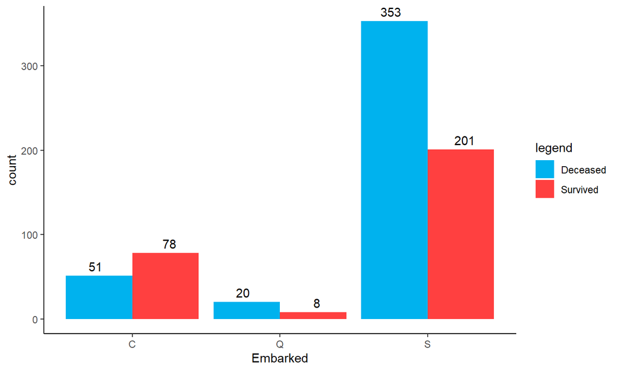

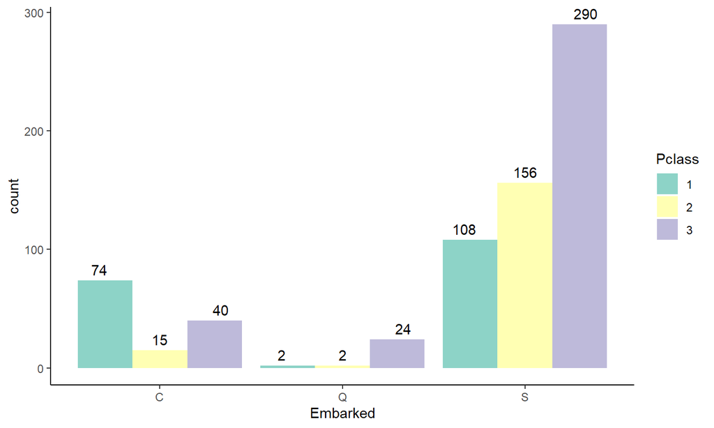

## Come varia il prezzo della tariffa del biglietto?

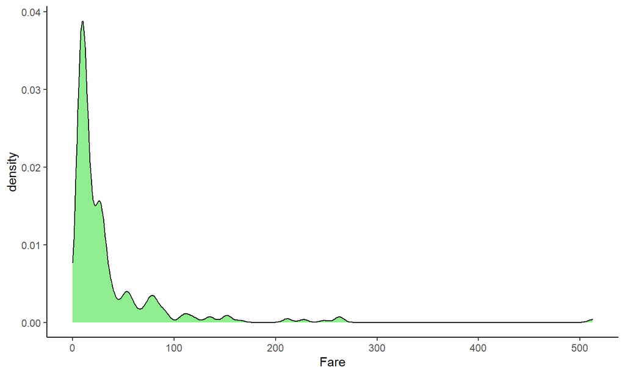

## Come varia il prezzo rispetto ad ogni classe di appartenenza?

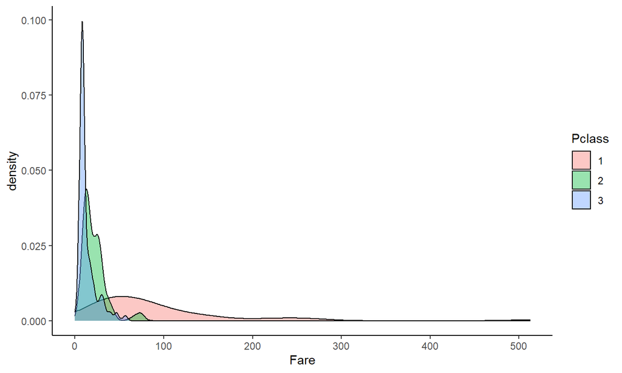

## Erano di più le famiglie o le persone che viaggiavano da sole?

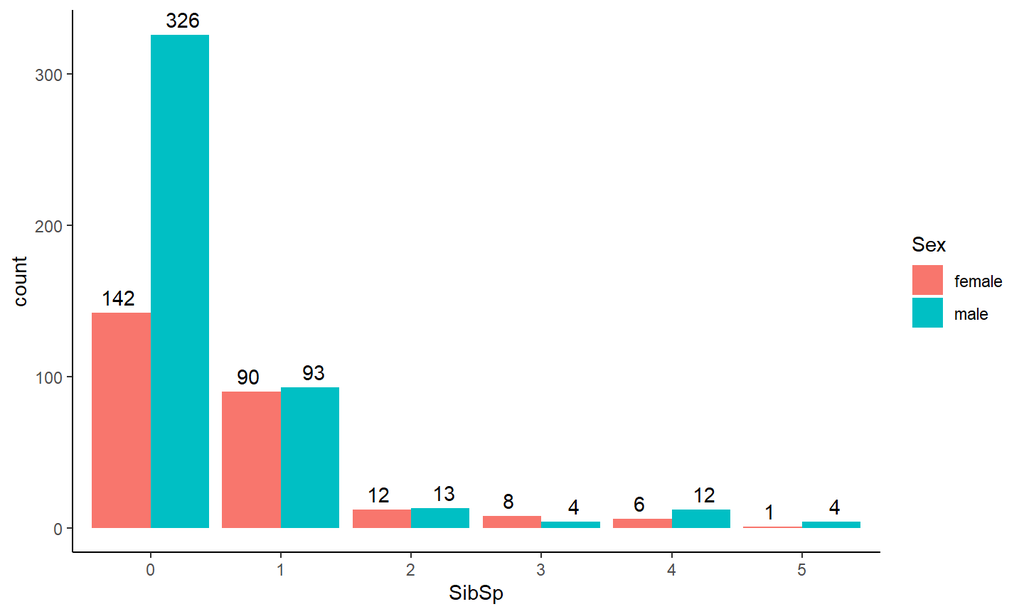

## MATRICE DI CORRELAZIONE

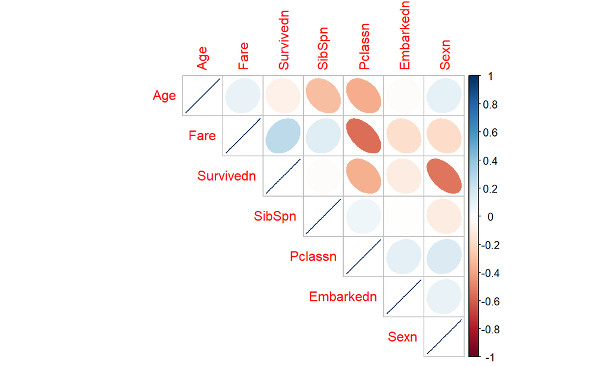

## CONCLUSIONI

- Sono sopravvissute più donne rispetto agli uomini
- La maggior parte dei passeggeri aveva un’età compresa tra i 20 e i 40 anni
- La priorità di salvezza è stata data per lo più ai bambini e alle donne
- Esiste una correlazione tra sopravvivenza e appartenenza ad una classe piuttosto che ad un’altra
- Esiste una correlazione abbastanza accentuata tra sopravvivenza e sesso
- Esiste una correlazione tra prezzo della tariffa e sopravvivenza